# Climate vs Productivity Analysis - BrazilAgriAnalysis

## Agricultural Capital

```r
muni_sum <- maize1ACmeans_l %>%
  group_by(year, StateNM, RegionNM) %>%
  summarize(meanmaize1 = mean(maize1),
            sdmaize1   = sd(maize1),
            meanAC = mean(meanAC),
            sdAC = sd(meanAC)) %>%
  ungroup()

state_sum <- muni_sum %>%
  group_by(StateNM) %>%
  summarise(meanmaize1Period = mean(meanmaize1),
    meanACPeriod = mean(meanAC)) %>%
  ungroup()

muni_states <- left_join(muni_sum, state_sum)

muni_states <- muni_states %>%
  group_by(year, StateNM, RegionNM) %>%
  summarize(diffcmaize1Period = meanmaize1 - meanmaize1Period,
    diffcACPeriod= meanAC - meanACPeriod ) %>%
  ungroup()

muni_sum <- left_join(muni_sum, muni_states, b = c("year"="year","StateNM"="StateNM","RegionNM"="RegionNM"))
```

### Time Series

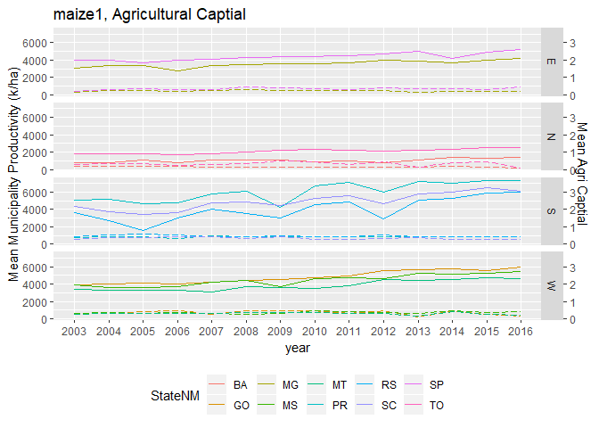

```r
muni_sum %>%
  ggplot(aes(x=year, group=StateNM)) +
  geom_line(aes(y=meanmaize1, colour=StateNM)) +
  geom_line(aes(y=meanAC*2000, colour=StateNM), linetype="longdash") +
  scale_y_continuous(sec.axis = sec_axis(~./2000, name = "Mean Agri Captial")) +
  facet_grid(RegionNM~.) +
  ggtitle("maize1, Agricultural Captial") +
  ylab("Mean Municipality Productivity (k/ha)") +
  theme(legend.position = "bottom")
```

Dotted line is climate variable

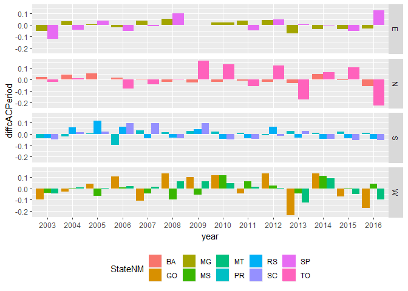

```r
muni_sum %>%
  ggplot(aes(x=year, y=diffcACPeriod, group=StateNM)) +
  geom_bar(stat="identity", position="dodge", aes(fill=StateNM)) +
  facet_grid(RegionNM~.) +
  theme(legend.position = "bottom")
```

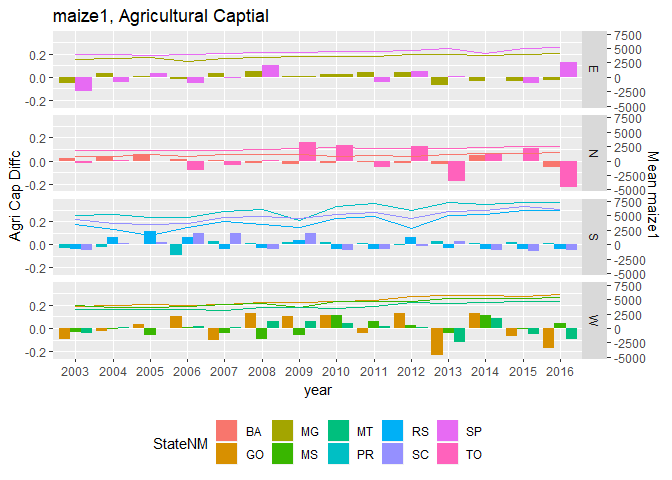

```r
muni_sum %>%
  ggplot(aes(x=year, y=diffcACPeriod, group=StateNM)) +
  geom_bar(stat="identity", position="dodge", aes(fill=StateNM)) +
  geom_line(aes(y=meanmaize1/20000, colour=StateNM)) +
  scale_y_continuous(sec.axis = sec_axis(~.*20000, name = "Mean maize1")) +
  facet_grid(RegionNM~.) +
  ggtitle("maize1, Agricultural Captial") +
  ylab("Agri Cap Diffc") +
  theme(legend.position = "bottom")
```

Differences are from the mean value for the period 2003-2016

### Scatter (points are years)

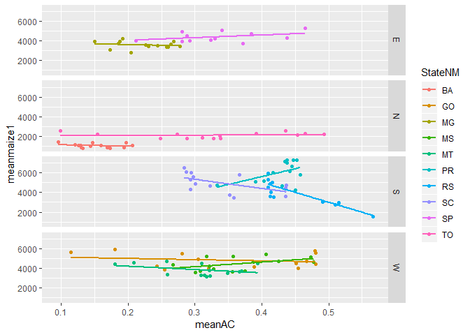

```r
muni_sum %>%
  ggplot(aes(x=meanAC, y=meanmaize1)) +
  geom_point(aes(colour=StateNM)) +
  geom_smooth(aes(group=StateNM, colour = StateNM),method=lm, se=F) +
  facet_grid(RegionNM~.)
```

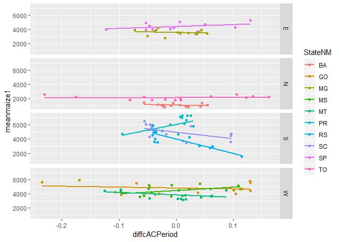

```r
muni_sum %>%
  ggplot(aes(x=diffcACPeriod, y=meanmaize1)) +
  geom_point(aes(colour=StateNM)) +
  geom_smooth(aes(group=StateNM, colour = StateNM),method=lm, se=F) +
  facet_grid(RegionNM~.)
```

## DEF months count

```r
muni_sum <- maize1DEFcmeans_l %>%
  group_by(year, StateNM, RegionNM) %>%
  summarize(meanmaize1 = mean(maize1),
            sdmaize1   = sd(maize1),
            meanDEFc = mean(meanDEFc),
            sdDEFc = sd(meanDEFc) ) %>%
  ungroup()

state_sum <- muni_sum %>%
  group_by(StateNM) %>%
  summarise(meanmaize1Period = mean(meanmaize1),
    meanDEFcPeriod = mean(meanDEFc)) %>%
  ungroup()

muni_states <- left_join(muni_sum, state_sum)

muni_states <- muni_states %>%
  group_by(year, StateNM, RegionNM) %>%
  summarize(diffcmaize1Period = meanmaize1 - meanmaize1Period,
    diffcDEFcPeriod= meanDEFc - meanDEFcPeriod) %>%
  ungroup()

muni_sum <- left_join(muni_sum, muni_states, b = c("year"="year","StateNM"="StateNM","RegionNM"="RegionNM"))
```

### Time Series

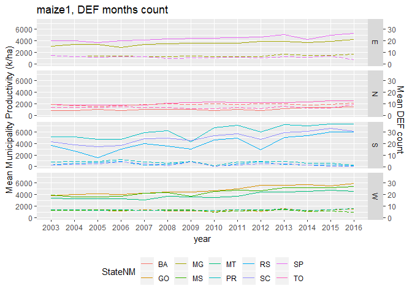

```r
muni_sum %>%
  ggplot(aes(x=year, group=StateNM)) +
  geom_line(aes(y=meanmaize1, colour=StateNM)) +
  geom_line(aes(y=meanDEFc*200, colour=StateNM), linetype="longdash") +
  scale_y_continuous(sec.axis = sec_axis(~./200, name = "Mean DEF count")) +
  facet_grid(RegionNM~.) +
  ggtitle("maize1, DEF months count") +
  ylab("Mean Municipality Productivity (k/ha)") +
  theme(legend.position = "bottom")
```

Dotted line is climate variable

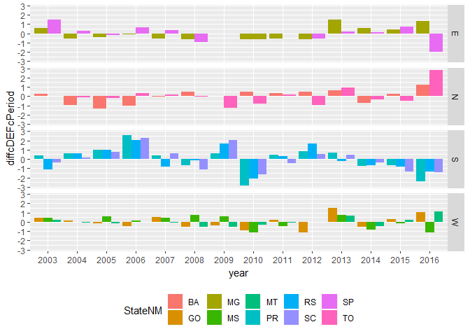

```r
muni_sum %>%
  ggplot(aes(x=year, y=diffcDEFcPeriod, group=StateNM)) +
  geom_bar(stat="identity", position="dodge", aes(fill=StateNM)) +
  facet_grid(RegionNM~.)  +
  theme(legend.position = "bottom")
```

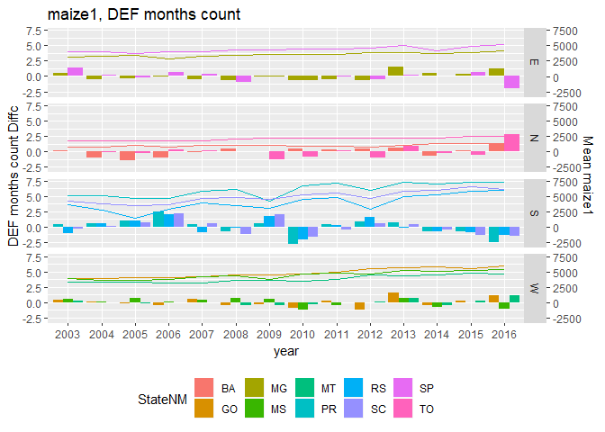

```r
muni_sum %>%
  ggplot(aes(x=year, y=diffcDEFcPeriod, group=StateNM)) +
  geom_bar(stat="identity", position="dodge", aes(fill=StateNM)) +
  geom_line(aes(y=meanmaize1/1000, colour=StateNM)) +
  scale_y_continuous(sec.axis = sec_axis(~.*1000, name = "Mean maize1")) +
  facet_grid(RegionNM~.) +
  ggtitle("maize1, DEF months count") +
  ylab("DEF months count Diffc") +
  theme(legend.position = "bottom")
```

Differences are from the mean value for the period 2003-2016

### Scatter (points are years)

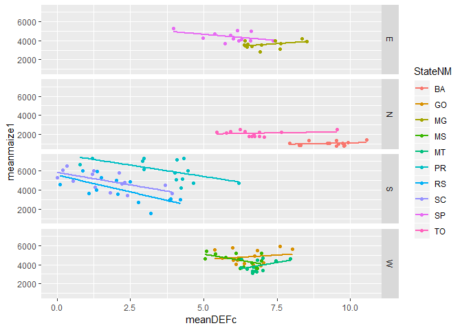

```r
muni_sum %>%
  ggplot(aes(x=meanDEFc, y=meanmaize1)) +
  geom_point(aes(colour=StateNM)) +
  geom_smooth(aes(group=StateNM, colour = StateNM),method=lm, se=F) +
  facet_grid(RegionNM~.)
```

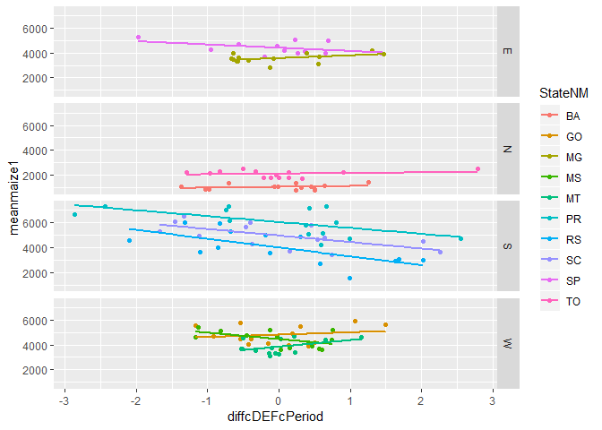

```r
muni_sum %>%
  ggplot(aes(x=diffcDEFcPeriod, y=meanmaize1)) +
  geom_point(aes(colour=StateNM)) +
  geom_smooth(aes(group=StateNM, colour = StateNM),method=lm, se=F) +
  facet_grid(RegionNM~.)
```

## DEF months mean

```r
muni_sum <- maize1DEFmmeans_l %>%
  group_by(year, StateNM, RegionNM) %>%
  summarize(meanmaize1 = mean(maize1),
            sdmaize1   = sd(maize1),
            meanDEFm = mean(meanDEFm),
            sdDEFm = sd(meanDEFm) ) %>%
  ungroup()

state_sum <- muni_sum %>%
  group_by(StateNM) %>%
  summarise(meanmaize1Period = mean(meanmaize1),
    meanDEFmPeriod = mean(meanDEFm)) %>%
  ungroup()

muni_states <- left_join(muni_sum, state_sum)

muni_states <- muni_states %>%
  group_by(year, StateNM, RegionNM) %>%
  summarize(diffcmaize1Period = meanmaize1 - meanmaize1Period,
    diffcDEFmPeriod= meanDEFm - meanDEFmPeriod) %>%
  ungroup()

muni_sum <- left_join(muni_sum, muni_states, b = c("year"="year","StateNM"="StateNM","RegionNM"="RegionNM"))
```

### Time Series

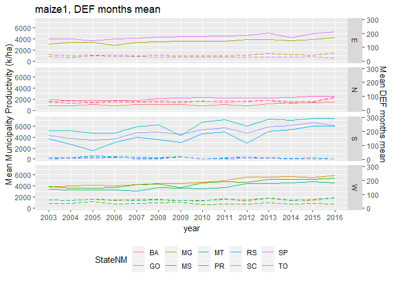

```r
muni_sum %>%
  ggplot(aes(x=year, group=StateNM)) +
  geom_line(aes(y=meanmaize1, colour=StateNM)) +
  geom_line(aes(y=meanDEFm*25, colour=StateNM), linetype="longdash") +
  scale_y_continuous(sec.axis = sec_axis(~./25, name = "Mean DEF months mean")) +
  facet_grid(RegionNM~.) +
  ggtitle("maize1, DEF months mean") +
  ylab("Mean Municipality Productivity (k/ha)") +
  theme(legend.position = "bottom")
```

Dotted line is climate variable

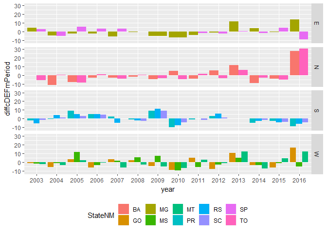

```r
muni_sum %>%
  ggplot(aes(x=year, y=diffcDEFmPeriod, group=StateNM)) +
  geom_bar(stat="identity", position="dodge", aes(fill=StateNM)) +
  facet_grid(RegionNM~.)  +
  theme(legend.position = "bottom")
```

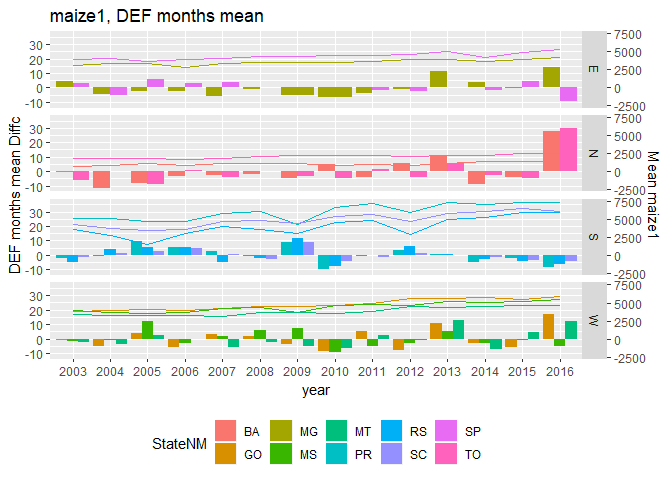

```r
muni_sum %>%
  ggplot(aes(x=year, y=diffcDEFmPeriod, group=StateNM)) +
  geom_bar(stat="identity", position="dodge", aes(fill=StateNM)) +
  geom_line(aes(y=meanmaize1/200, colour=StateNM)) +
  scale_y_continuous(sec.axis = sec_axis(~.*200, name = "Mean maize1")) +
  facet_grid(RegionNM~.) +
  ggtitle("maize1, DEF months mean") +
  ylab("DEF months mean Diffc") +
  theme(legend.position = "bottom")
```

Differences are from the mean value for the period 2003-2016

### Scatter (points are years)

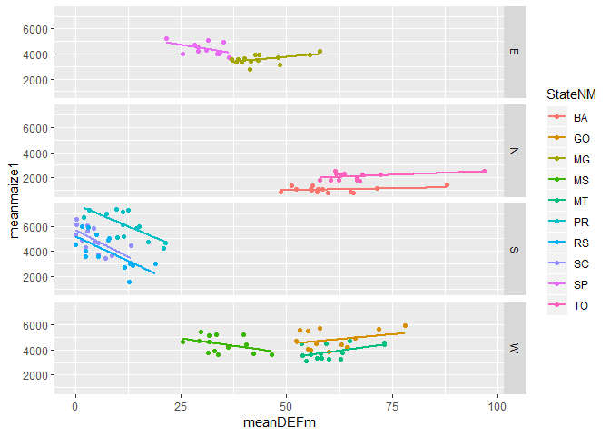

```r
muni_sum %>%
  ggplot(aes(x=meanDEFm, y=meanmaize1)) +
  geom_point(aes(colour=StateNM)) +
  geom_smooth(aes(group=StateNM, colour = StateNM),method=lm, se=F) +
  facet_grid(RegionNM~.)
```

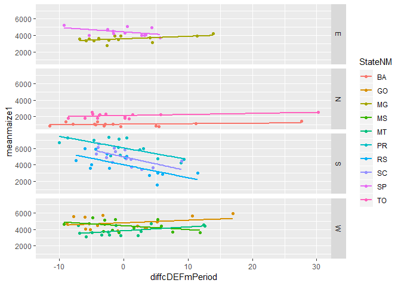

```r
muni_sum %>%
  ggplot(aes(x=diffcDEFmPeriod, y=meanmaize1)) +
  geom_point(aes(colour=StateNM)) +
  geom_smooth(aes(group=StateNM, colour = StateNM),method=lm, se=F) +
  facet_grid(RegionNM~.)
```

## Dryness Index

```r
muni_sum <- maize1DImeans_l %>%
  group_by(year, StateNM, RegionNM) %>%
  summarize(meanmaize1 = mean(maize1),
            sdmaize1   = sd(maize1),
            meanDI = mean(meanDI),
            sdDI = sd(meanDI) ) %>%
  ungroup()

state_sum <- muni_sum %>%
  group_by(StateNM) %>%
  summarise(meanmaize1Period = mean(meanmaize1),
    meanDIPeriod = mean(meanDI)) %>%
  ungroup()

muni_states <- left_join(muni_sum, state_sum)

muni_states <- muni_states %>%
  group_by(year, StateNM, RegionNM) %>%
  summarize(
    diffcmaize1Period = meanmaize1 - meanmaize1Period,
    diffcDIPeriod= meanDI - meanDIPeriod) %>%
  ungroup()

muni_sum <- left_join(muni_sum, muni_states, b = c("year"="year","StateNM"="StateNM","RegionNM"="RegionNM"))
```

### Time Series

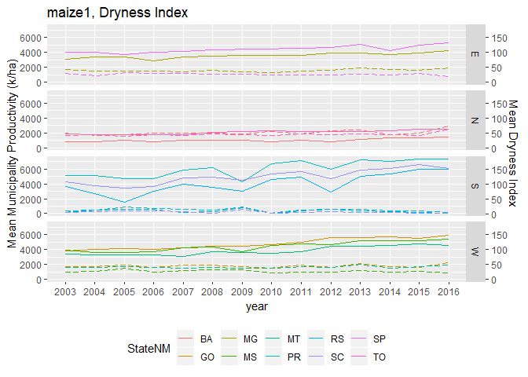

```r
muni_sum %>%
  ggplot(aes(x=year, group=StateNM)) +
  geom_line(aes(y=meanmaize1, colour=StateNM)) +
  geom_line(aes(y=meanDI*40, colour=StateNM), linetype="longdash") +
  scale_y_continuous(sec.axis = sec_axis(~./40, name = "Mean Dryness Index")) +
  facet_grid(RegionNM~.) +
  ggtitle("maize1, Dryness Index") +
  ylab("Mean Municipality Productivity (k/ha)") +
  theme(legend.position = "bottom")
```

Dotted line is climate variable

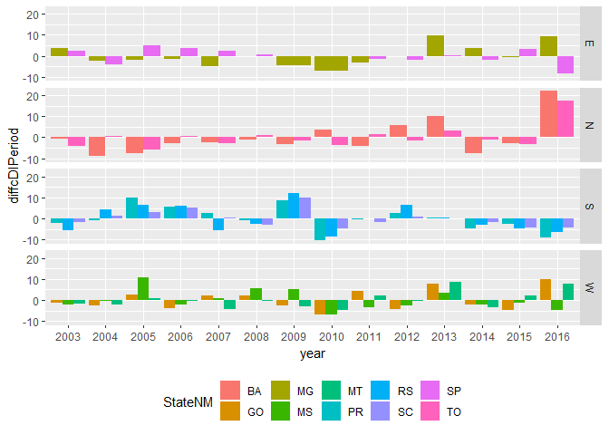

```r
muni_sum %>%
  ggplot(aes(x=year, y=diffcDIPeriod, group=StateNM)) +
  geom_bar(stat="identity", position="dodge", aes(fill=StateNM)) +
  facet_grid(RegionNM~.)  +
  theme(legend.position = "bottom")
```

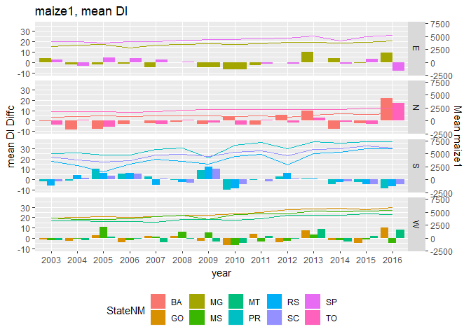

```r
muni_sum %>%
  ggplot(aes(x=year, y=diffcDIPeriod, group=StateNM)) +
  geom_bar(stat="identity", position="dodge", aes(fill=StateNM)) +
  geom_line(aes(y=meanmaize1/200, colour=StateNM)) +
  scale_y_continuous(sec.axis = sec_axis(~.*200, name = "Mean maize1")) +
  facet_grid(RegionNM~.) +
  ggtitle("maize1, mean DI") +
  ylab("mean DI Diffc") +
  theme(legend.position = "bottom")
```

Differences are from the mean value for the period 2003-2016

### Scatter (points are years)

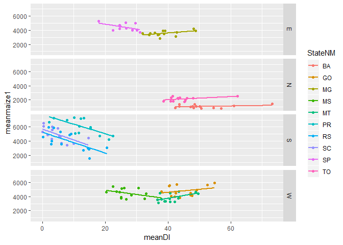

```r
muni_sum %>%
  ggplot(aes(x=meanDI, y=meanmaize1)) +
  geom_point(aes(colour=StateNM)) +
  geom_smooth(aes(group=StateNM, colour = StateNM),method=lm, se=F) +
  facet_grid(RegionNM~.)
```

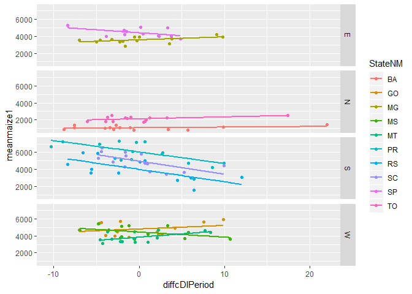

```r
muni_sum %>%
  ggplot(aes(x=diffcDIPeriod, y=meanmaize1)) +
  geom_point(aes(colour=StateNM)) +
  geom_smooth(aes(group=StateNM, colour = StateNM),method=lm, se=F) +
  facet_grid(RegionNM~.)
```

# Maize 2

## Climate Limitation

```r
muni_sum <- maize2CLmeans_l %>%
  group_by(year, StateNM, RegionNM) %>%
  summarize(meanmaize2 = mean(maize2),
            sdmaize2   = sd(maize2),
            meanCL = mean(meanCL),
            sdCL = sd(meanCL) ) %>%
  ungroup()

state_sum <- muni_sum %>%
  group_by(StateNM) %>%
  summarise(meanmaize2Period = mean(meanmaize2),
    meanCLPeriod = mean(meanCL)) %>%
  ungroup()

muni_states <- left_join(muni_sum, state_sum)

muni_states <- muni_states %>%
  group_by(year, StateNM, RegionNM) %>%
  summarize(diffcmaize2Period = meanmaize2 - meanmaize2Period,
    diffcCLPeriod= meanCL - meanCLPeriod ) %>%
  ungroup()

muni_sum <- left_join(muni_sum, muni_states, b = c("year"="year","StateNM"="StateNM","RegionNM"="RegionNM"))
```

### Time Series

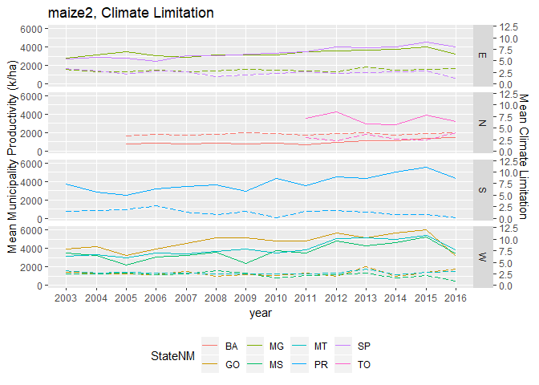

```r
muni_sum %>%
  ggplot(aes(x=year, group=StateNM)) +
  geom_line(aes(y=meanmaize2, colour=StateNM)) +
  geom_line(aes(y=meanCL*500, colour=StateNM), linetype="longdash") +
  scale_y_continuous(sec.axis = sec_axis(~./500, name = "Mean Climate Limitation")) +
  facet_grid(RegionNM~.) +
  ggtitle("maize2, Climate Limitation") +
  ylab("Mean Municipality Productivity (k/ha)") +
  theme(legend.position = "bottom")
```

Dotted line is climate variable

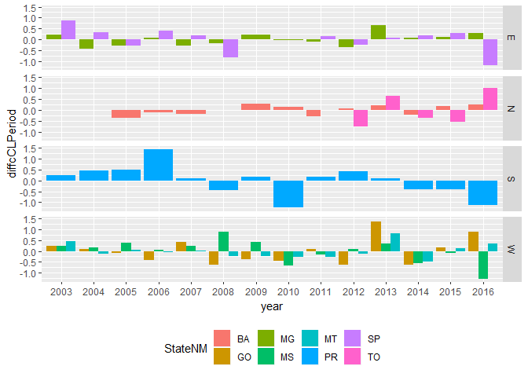

```r
muni_sum %>%
  ggplot(aes(x=year, y=diffcCLPeriod, group=StateNM)) +
  geom_bar(stat="identity", position="dodge", aes(fill=StateNM)) +
  facet_grid(RegionNM~.) +
  theme(legend.position = "bottom")
```

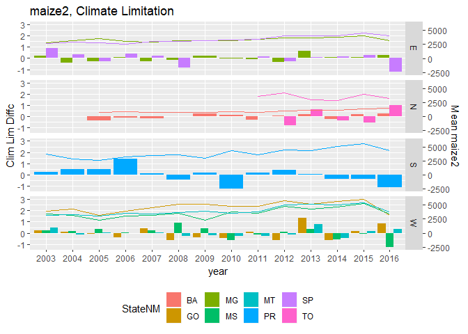

```r
muni_sum %>%
  ggplot(aes(x=year, y=diffcCLPeriod, group=StateNM)) +
  geom_bar(stat="identity", position="dodge", aes(fill=StateNM)) +
  geom_line(aes(y=meanmaize2/2000, colour=StateNM)) +
  scale_y_continuous(sec.axis = sec_axis(~.*2000, name = "Mean maize2")) +
  facet_grid(RegionNM~.) +
  ggtitle("maize2, Climate Limitation") +
  ylab("Clim Lim Diffc") +
  theme(legend.position = "bottom")
```

Differences are from the mean value for the period 2003-2016

### Scatter (points are years)

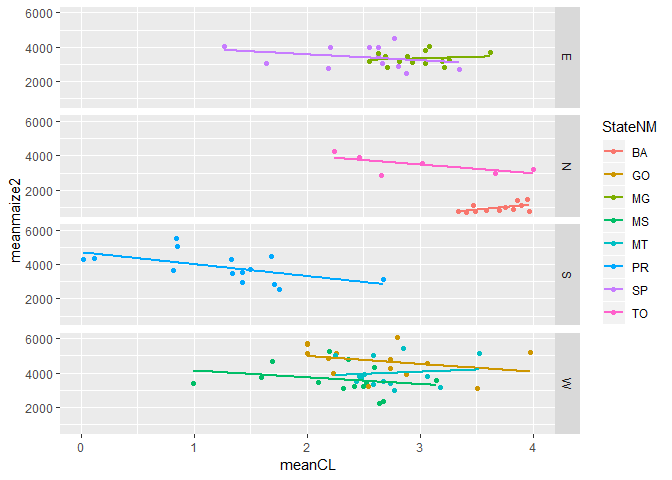

```r
muni_sum %>%
  ggplot(aes(x=meanCL, y=meanmaize2)) +
  geom_point(aes(colour=StateNM)) +
  geom_smooth(aes(group=StateNM, colour = StateNM),method=lm, se=F) +
  facet_grid(RegionNM~.)
```

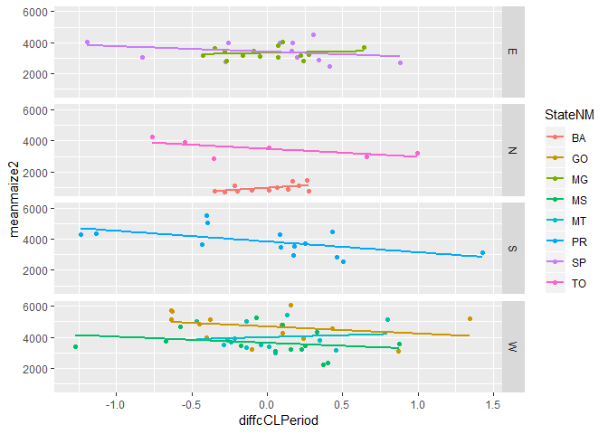

```r
muni_sum %>%
  ggplot(aes(x=diffcCLPeriod, y=meanmaize2)) +
  geom_point(aes(colour=StateNM)) +
  geom_smooth(aes(group=StateNM, colour = StateNM),method=lm, se=F) +
  facet_grid(RegionNM~.)
```

## Agricultural Capital

```r
muni_sum <- maize2ACmeans_l %>%
  group_by(year, StateNM, RegionNM) %>%
  summarize(meanmaize2 = mean(maize2),
            sdmaize2   = sd(maize2),
            meanAC = mean(meanAC),
            sdAC = sd(meanAC)) %>%
  ungroup()

state_sum <- muni_sum %>%
  group_by(StateNM) %>%
  summarise(meanmaize2Period = mean(meanmaize2),
    meanACPeriod = mean(meanAC)) %>%
  ungroup()

muni_states <- left_join(muni_sum, state_sum)

muni_states <- muni_states %>%
  group_by(year, StateNM, RegionNM) %>%
  summarize(diffcmaize2Period = meanmaize2 - meanmaize2Period,
    diffcACPeriod= meanAC - meanACPeriod ) %>%
  ungroup()

muni_sum <- left_join(muni_sum, muni_states, b = c("year"="year","StateNM"="StateNM","RegionNM"="RegionNM"))
```

### Time Series

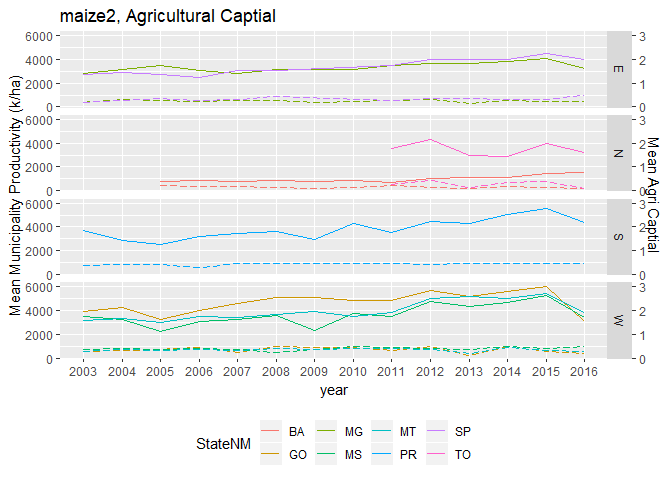

```r
muni_sum %>%
  ggplot(aes(x=year, group=StateNM)) +
  geom_line(aes(y=meanmaize2, colour=StateNM)) +
  geom_line(aes(y=meanAC*2000, colour=StateNM), linetype="longdash") +
  scale_y_continuous(sec.axis = sec_axis(~./2000, name = "Mean Agri Captial")) +
  facet_grid(RegionNM~.) +
  ggtitle("maize2, Agricultural Captial") +
  ylab("Mean Municipality Productivity (k/ha)") +
  theme(legend.position = "bottom")
```

Dotted line is climate variable

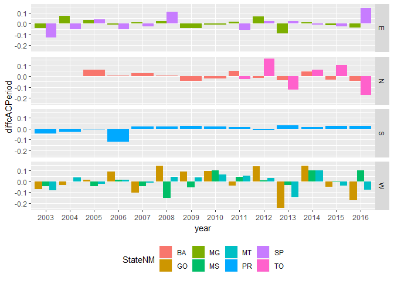

```r
muni_sum %>%
  ggplot(aes(x=year, y=diffcACPeriod, group=StateNM)) +
  geom_bar(stat="identity", position="dodge", aes(fill=StateNM)) +
  facet_grid(RegionNM~.) +
  theme(legend.position = "bottom")
```

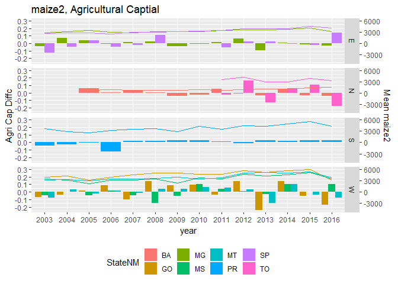

```r
muni_sum %>%
  ggplot(aes(x=year, y=diffcACPeriod, group=StateNM)) +
  geom_bar(stat="identity", position="dodge", aes(fill=StateNM)) +
  geom_line(aes(y=meanmaize2/20000, colour=StateNM)) +
  scale_y_continuous(sec.axis = sec_axis(~.*20000, name = "Mean maize2")) +
  facet_grid(RegionNM~.) +
  ggtitle("maize2, Agricultural Captial") +
  ylab("Agri Cap Diffc") +
  theme(legend.position = "bottom")
```

Differences are from the mean value for the period 2003-2016

### Scatter (points are years)

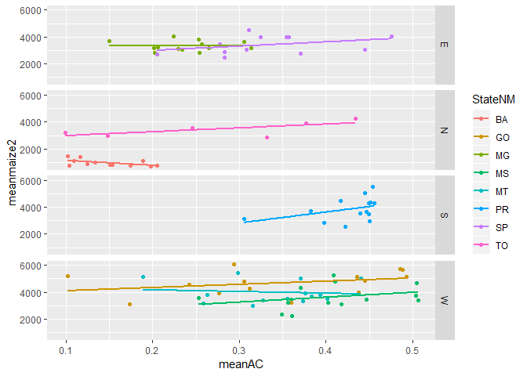

```r
muni_sum %>%
  ggplot(aes(x=meanAC, y=meanmaize2)) +
  geom_point(aes(colour=StateNM)) +
  geom_smooth(aes(group=StateNM, colour = StateNM),method=lm, se=F) +
  facet_grid(RegionNM~.)
```

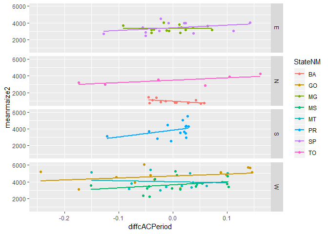

```r
muni_sum %>%
  ggplot(aes(x=diffcACPeriod, y=meanmaize2)) +
  geom_point(aes(colour=StateNM)) +
  geom_smooth(aes(group=StateNM, colour = StateNM),method=lm, se=F) +
  facet_grid(RegionNM~.)
```

## DEF months count

```r
muni_sum <- maize2DEFcmeans_l %>%
  group_by(year, StateNM, RegionNM) %>%
  summarize(meanmaize2 = mean(maize2),
            sdmaize2   = sd(maize2),
            meanDEFc = mean(meanDEFc),
            sdDEFc = sd(meanDEFc) ) %>%
  ungroup()

state_sum <- muni_sum %>%
  group_by(StateNM) %>%
  summarise(meanmaize2Period = mean(meanmaize2),
    meanDEFcPeriod = mean(meanDEFc)) %>%
  ungroup()

muni_states <- left_join(muni_sum, state_sum)

muni_states <- muni_states %>%
  group_by(year, StateNM, RegionNM) %>%
  summarize(diffcmaize2Period = meanmaize2 - meanmaize2Period,
    diffcDEFcPeriod= meanDEFc - meanDEFcPeriod) %>%
  ungroup()

muni_sum <- left_join(muni_sum, muni_states, b = c("year"="year","StateNM"="StateNM","RegionNM"="RegionNM"))
```

### Time Series

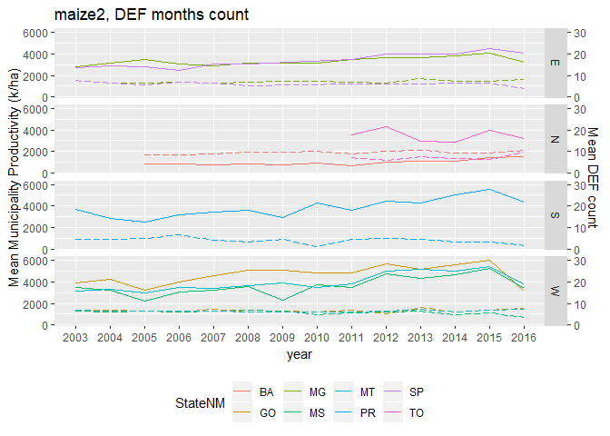

```r
muni_sum %>%
  ggplot(aes(x=year, group=StateNM)) +
  geom_line(aes(y=meanmaize2, colour=StateNM)) +
  geom_line(aes(y=meanDEFc*200, colour=StateNM), linetype="longdash") +
  scale_y_continuous(sec.axis = sec_axis(~./200, name = "Mean DEF count")) +
  facet_grid(RegionNM~.) +
  ggtitle("maize2, DEF months count") +
  ylab("Mean Municipality Productivity (k/ha)") +
  theme(legend.position = "bottom")
```

Dotted line is climate variable

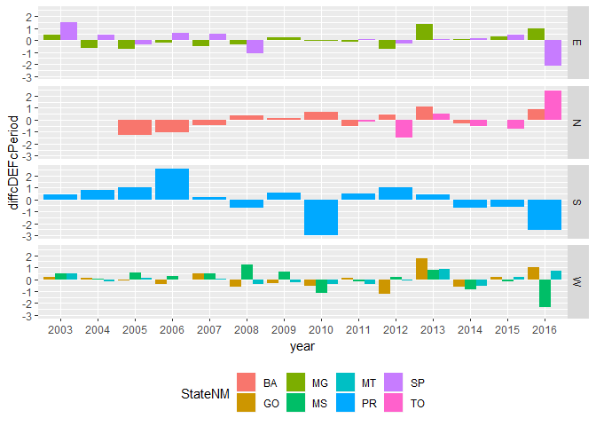

```r
muni_sum %>%
  ggplot(aes(x=year, y=diffcDEFcPeriod, group=StateNM)) +
  geom_bar(stat="identity", position="dodge", aes(fill=StateNM)) +
  facet_grid(RegionNM~.)  +
  theme(legend.position = "bottom")
```

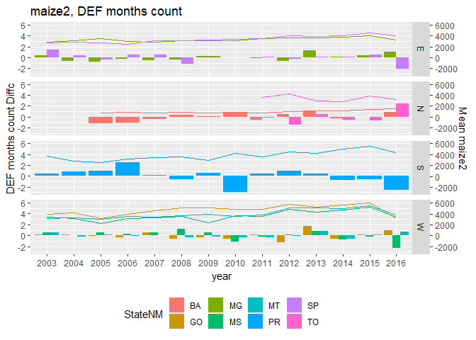

```r
muni_sum %>%
  ggplot(aes(x=year, y=diffcDEFcPeriod, group=StateNM)) +
  geom_bar(stat="identity", position="dodge", aes(fill=StateNM)) +
  geom_line(aes(y=meanmaize2/1000, colour=StateNM)) +
  scale_y_continuous(sec.axis = sec_axis(~.*1000, name = "Mean maize2")) +
  facet_grid(RegionNM~.) +
  ggtitle("maize2, DEF months count") +
  ylab("DEF months count Diffc") +
  theme(legend.position = "bottom")
```

Differences are from the mean value for the period 2003-2016

### Scatter (points are years)

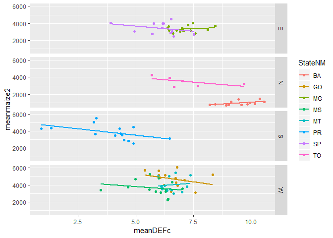

```r
muni_sum %>%
  ggplot(aes(x=meanDEFc, y=meanmaize2)) +
  geom_point(aes(colour=StateNM)) +
  geom_smooth(aes(group=StateNM, colour = StateNM),method=lm, se=F) +
  facet_grid(RegionNM~.)
```

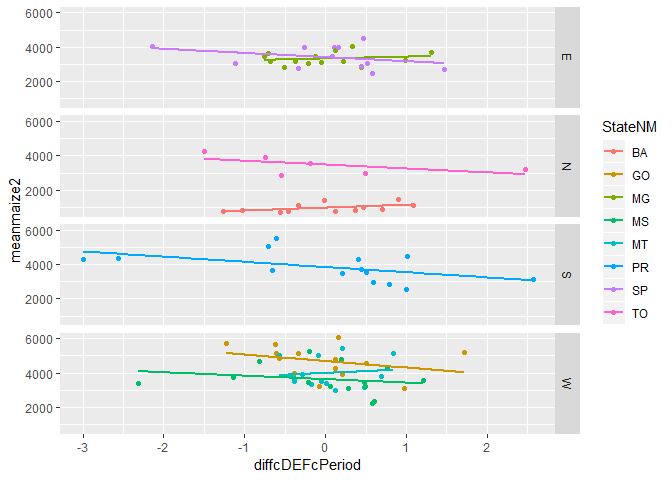

```r
muni_sum %>%
  ggplot(aes(x=diffcDEFcPeriod, y=meanmaize2)) +
  geom_point(aes(colour=StateNM)) +
  geom_smooth(aes(group=StateNM, colour = StateNM),method=lm, se=F) +
  facet_grid(RegionNM~.)
```

## DEF months mean

```r
muni_sum <- maize2DEFmmeans_l %>%
  group_by(year, StateNM, RegionNM) %>%
  summarize(meanmaize2 = mean(maize2),
            sdmaize2   = sd(maize2),
            meanDEFm = mean(meanDEFm),
            sdDEFm = sd(meanDEFm) ) %>%
  ungroup()

state_sum <- muni_sum %>%
  group_by(StateNM) %>%
  summarise(meanmaize2Period = mean(meanmaize2),
    meanDEFmPeriod = mean(meanDEFm)) %>%
  ungroup()

muni_states <- left_join(muni_sum, state_sum)

muni_states <- muni_states %>%
  group_by(year, StateNM, RegionNM) %>%
  summarize(diffcmaize2Period = meanmaize2 - meanmaize2Period,
    diffcDEFmPeriod= meanDEFm - meanDEFmPeriod) %>%
  ungroup()

muni_sum <- left_join(muni_sum, muni_states, b = c("year"="year","StateNM"="StateNM","RegionNM"="RegionNM"))
```

### Time Series

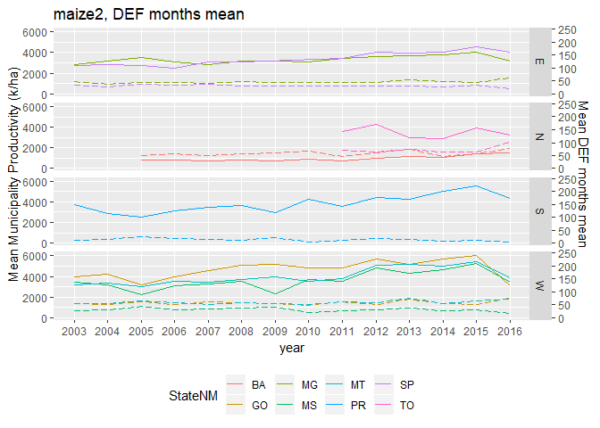

```r
muni_sum %>%
  ggplot(aes(x=year, group=StateNM)) +
  geom_line(aes(y=meanmaize2, colour=StateNM)) +
  geom_line(aes(y=meanDEFm*25, colour=StateNM), linetype="longdash") +
  scale_y_continuous(sec.axis = sec_axis(~./25, name = "Mean DEF months mean")) +
  facet_grid(RegionNM~.) +
  ggtitle("maize2, DEF months mean") +
  ylab("Mean Municipality Productivity (k/ha)") +
  theme(legend.position = "bottom")
```

Dotted line is climate variable

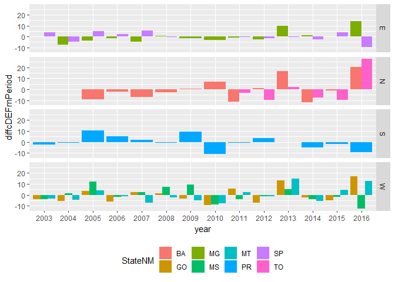

```r
muni_sum %>%
  ggplot(aes(x=year, y=diffcDEFmPeriod, group=StateNM)) +
  geom_bar(stat="identity", position="dodge", aes(fill=StateNM)) +
  facet_grid(RegionNM~.)  +
  theme(legend.position = "bottom")
```

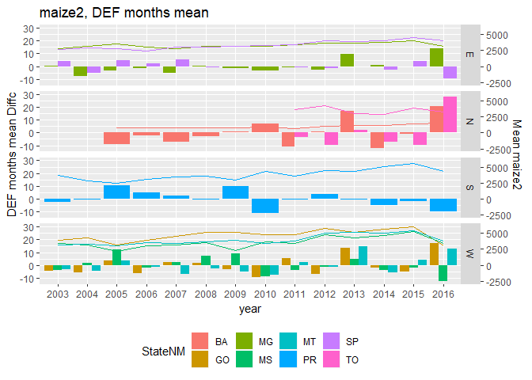

```r
muni_sum %>%
  ggplot(aes(x=year, y=diffcDEFmPeriod, group=StateNM)) +
  geom_bar(stat="identity", position="dodge", aes(fill=StateNM)) +
  geom_line(aes(y=meanmaize2/200, colour=StateNM)) +
  scale_y_continuous(sec.axis = sec_axis(~.*200, name = "Mean maize2")) +
  facet_grid(RegionNM~.) +
  ggtitle("maize2, DEF months mean") +
  ylab("DEF months mean Diffc") +
  theme(legend.position = "bottom")
```

Differences are from the mean value for the period 2003-2016

### Scatter (points are years)

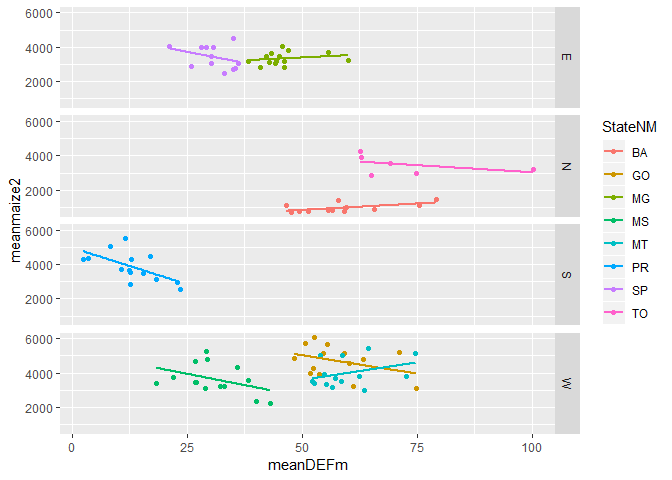

```r
muni_sum %>%
  ggplot(aes(x=meanDEFm, y=meanmaize2)) +
  geom_point(aes(colour=StateNM)) +
  geom_smooth(aes(group=StateNM, colour = StateNM),method=lm, se=F) +
  facet_grid(RegionNM~.)
```

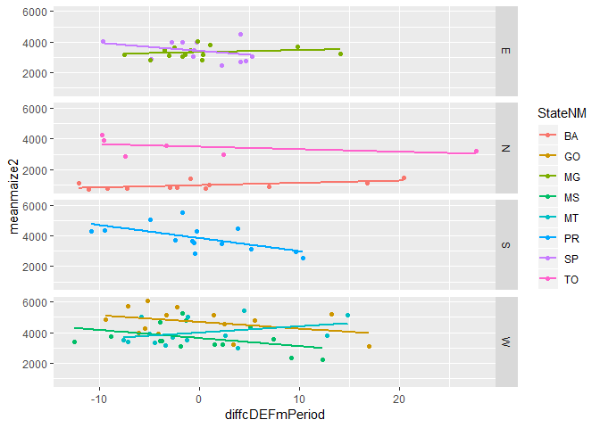

```r
muni_sum %>%
  ggplot(aes(x=diffcDEFmPeriod, y=meanmaize2)) +
  geom_point(aes(colour=StateNM)) +
  geom_smooth(aes(group=StateNM, colour = StateNM),method=lm, se=F) +
  facet_grid(RegionNM~.)
```

## Dryness Index

```r
muni_sum <- maize2DImeans_l %>%
  group_by(year, StateNM, RegionNM) %>%
  summarize(meanmaize2 = mean(maize2),
            sdmaize2   = sd(maize2),
            meanDI = mean(meanDI),
            sdDI = sd(meanDI) ) %>%
  ungroup()

state_sum <- muni_sum %>%
  group_by(StateNM) %>%
  summarise(meanmaize2Period = mean(meanmaize2),
    meanDIPeriod = mean(meanDI)) %>%
  ungroup()

muni_states <- left_join(muni_sum, state_sum)

muni_states <- muni_states %>%
  group_by(year, StateNM, RegionNM) %>%
  summarize(
    diffcmaize2Period = meanmaize2 - meanmaize2Period,
    diffcDIPeriod= meanDI - meanDIPeriod) %>%
  ungroup()

muni_sum <- left_join(muni_sum, muni_states, b = c("year"="year","StateNM"="StateNM","RegionNM"="RegionNM"))
```

### Time Series

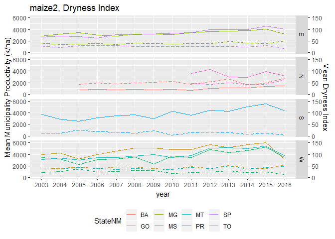

```r
muni_sum %>%
  ggplot(aes(x=year, group=StateNM)) +
  geom_line(aes(y=meanmaize2, colour=StateNM)) +
  geom_line(aes(y=meanDI*40, colour=StateNM), linetype="longdash") +
  scale_y_continuous(sec.axis = sec_axis(~./40, name = "Mean Dryness Index")) +
  facet_grid(RegionNM~.) +
  ggtitle("maize2, Dryness Index") +
  ylab("Mean Municipality Productivity (k/ha)") +
  theme(legend.position = "bottom")
```

Dotted line is climate variable

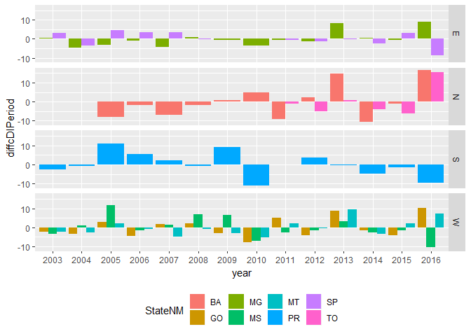

```r
muni_sum %>%
  ggplot(aes(x=year, y=diffcDIPeriod, group=StateNM)) +
  geom_bar(stat="identity", position="dodge", aes(fill=StateNM)) +
  facet_grid(RegionNM~.)  +
  theme(legend.position = "bottom")
```

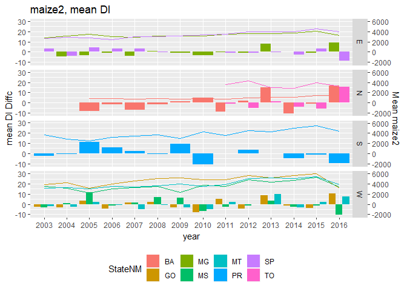

```r
muni_sum %>%
  ggplot(aes(x=year, y=diffcDIPeriod, group=StateNM)) +
  geom_bar(stat="identity", position="dodge", aes(fill=StateNM)) +
  geom_line(aes(y=meanmaize2/200, colour=StateNM)) +
  scale_y_continuous(sec.axis = sec_axis(~.*200, name = "Mean maize2")) +
  facet_grid(RegionNM~.) +
  ggtitle("maize2, mean DI") +
  ylab("mean DI Diffc") +
  theme(legend.position = "bottom")
```

Differences are from the mean value for the period 2003-2016

### Scatter (points are years)

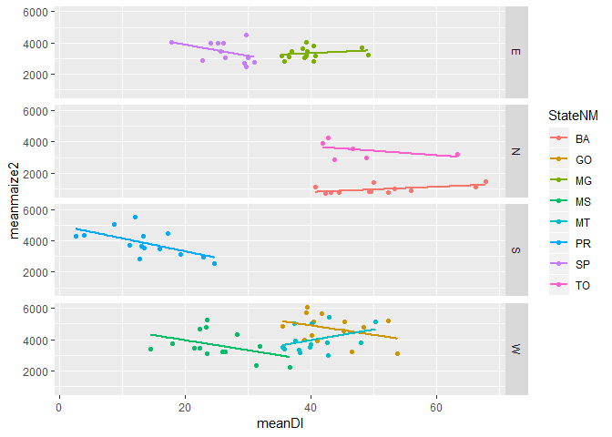

```r
muni_sum %>%
  ggplot(aes(x=meanDI, y=meanmaize2)) +
  geom_point(aes(colour=StateNM)) +
  geom_smooth(aes(group=StateNM, colour = StateNM),method=lm, se=F) +
  facet_grid(RegionNM~.)
```

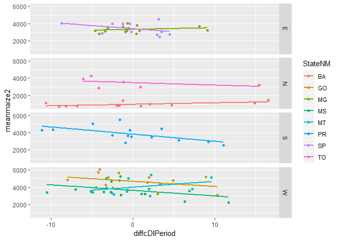

```r
muni_sum %>%
  ggplot(aes(x=diffcDIPeriod, y=meanmaize2)) +
  geom_point(aes(colour=StateNM)) +
  geom_smooth(aes(group=StateNM, colour = StateNM),method=lm, se=F) +
  facet_grid(RegionNM~.)
```